# Practical Machine Learning-Prediction Algorithm for Excercise Pattern

## Data Loading and Preprocessing-:

The first step includes loading the required packages for processing and the training and test datasets for building the algorithm.

```r
library(caret)
library(randomForest)
library(rpart)
```

```r
library(rpart.plot)
trainData<-read.csv("C:\\Users\\SHRUTI\\Documents\\practical machine learning\\pml-training(1).csv",na.strings=c("NA",""),header=TRUE)
testData<-read.csv("C:\\Users\\SHRUTI\\Documents\\practical machine learning\\pml-testing(1).csv",na.strings=c("NA",""),header=TRUE)

dim(trainData)
```

```
## [1] 19622   160
```

```r
dim(testData)
```

```
## [1]  20 160
```

This shows us that the training dataset has 19622 rows and 160 variables. The test dataset has 20 rows with 160 variables.

## Cleaning the Data

The data has lot of empty columns and columns which do not contribute towards the readings on the accelerometer. We clean the data to get rid of the unecessary columns.The number of complete cases in the data is 406.

```r
sum(complete.cases(trainData))
```

```
## [1] 406
```

```r
trainData<-trainData[,colSums(is.na(trainData))== 0]
testData<-testData[,colSums(is.na(testData))==0]
trainClean<- grepl("^X|timestamp|window", names(trainData))
trainData <- trainData[, !trainClean]
testClean<-grepl("^X|timestamp|window", names(testData))
testData <- testData[, !testClean]
```

The final dataset has just 54 columns left out of the initial 160.

## Separating the datasets into training and validation data sets-:

To build the prediction model we divide the dataset(mytrain) into two datasets- the training dataset(60%) and the validation dataset(40%).Setting the seed ensure that we can reproduce the results of the prediction algorithm.

```r
set.seed(22500)
inTrain<-createDataPartition(trainData$classe,p=0.60,list=FALSE)
mytrain<-trainData[inTrain,]
mytest<-trainData[-inTrain,]
dim(mytrain)
```

```
## [1] 11776    54
```

```r
dim(mytest)
```

```
## [1] 7846   54
```

## Building the Model-:

We use the (Random Forest Algorithm) with a (5- fold cross validation) to build our prediction model. We will also check the accuracy and the out of sample error for the model.

```r
control<-trainControl(method="cv",5)
Rfmodel<-train(classe ~.,data=mytrain,method="rf",trControl=control,ntree=250)
Rfmodel
```

```
## Random Forest
##
## 11776 samples
##    53 predictor
##     5 classes: 'A', 'B', 'C', 'D', 'E'
##
## No pre-processing
## Resampling: Cross-Validated (5 fold)
## Summary of sample sizes: 9422, 9421, 9420, 9421, 9420
## Resampling results across tuning parameters:
##
##   mtry  Accuracy   Kappa      Accuracy SD  Kappa SD
##    2    0.9861573  0.9824848  0.004850703  0.006139519
##   29    0.9878562  0.9846378  0.005048774  0.006384058
##   57    0.9843741  0.9802309  0.004243711  0.005367992
##
## Accuracy was used to select the optimal model using  the largest value.
## The final value used for the model was mtry = 29.
```

```r
prediction<-predict(Rfmodel,mytest)
confusionMatrix(mytest$classe,prediction)
```

```
## Confusion Matrix and Statistics
##
##           Reference
## Prediction    A    B    C    D    E
##          A 2228    1    2    0    1
##          B   13 1501    4    0    0
##          C    0   10 1355    3    0
##          D    0    0   10 1275    1
##          E    0    0    7    4 1431
##
## Overall Statistics
##
##                Accuracy : 0.9929
##                  95% CI : (0.9907, 0.9946)
##     No Information Rate : 0.2856
##     P-Value [Acc > NIR] : < 2.2e-16
##
##                   Kappa : 0.991
##  Mcnemar's Test P-Value : NA
##
## Statistics by Class:
##
##                      Class: A Class: B Class: C Class: D Class: E
## Sensitivity            0.9942   0.9927   0.9833   0.9945   0.9986
## Specificity            0.9993   0.9973   0.9980   0.9983   0.9983
## Pos Pred Value         0.9982   0.9888   0.9905   0.9914   0.9924
## Neg Pred Value         0.9977   0.9983   0.9964   0.9989   0.9997
## Prevalence             0.2856   0.1927   0.1756   0.1634   0.1826
## Detection Rate         0.2840   0.1913   0.1727   0.1625   0.1824
## Detection Prevalence   0.2845   0.1935   0.1744   0.1639   0.1838
## Balanced Accuracy      0.9967   0.9950   0.9906   0.9964   0.9984
```

We use tree visualization for the data to get a better idea of the model.

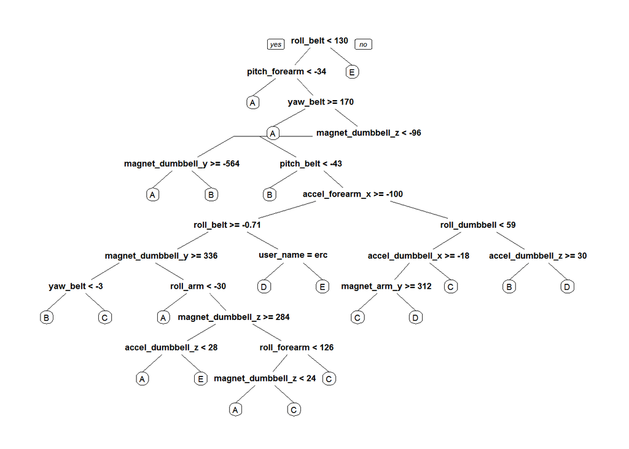

```r
treeModel <- rpart(classe ~ ., data=mytrain,method="class")
prp(treeModel)
```

```r
accuracy<-postResample(prediction,mytest$classe)
accuracy
```

```
##  Accuracy     Kappa
## 0.9928626 0.9909709
```

```r
outofsamplerror<-1-confusionMatrix(mytest$classe, prediction)$overall[1]
outofsamplerror
```

```
##    Accuracy
## 0.007137395
```

The accuracy of the model is 99.28% and the out of sample error is 0.71%.

## Testing the Model-:

Now we apply the prediction model to the dataset given for testing.

```r
finalresult<-predict(Rfmodel,testData)
finalresult
```

```
##  [1] B A B A A E D B A A B C B A E E A B B B
## Levels: A B C D E
```

## Project Program Submission-:

We use the following code chunk to create files for submission to 20 online test cases. The code creates 20 different files for submission to each problem.

```r
pml_write_files = function(x){
  n = length(x)
  for(i in 1:n){
    filename = paste0("problem_id_",i,".txt")
    write.table(x[i],file=filename,quote=FALSE,row.names=FALSE,col.names=FALSE)
  }
}
pml_write_files(finalresult)
```